# Homework 4

#### Fold 1

Parameter tuning results for the methods are provided below

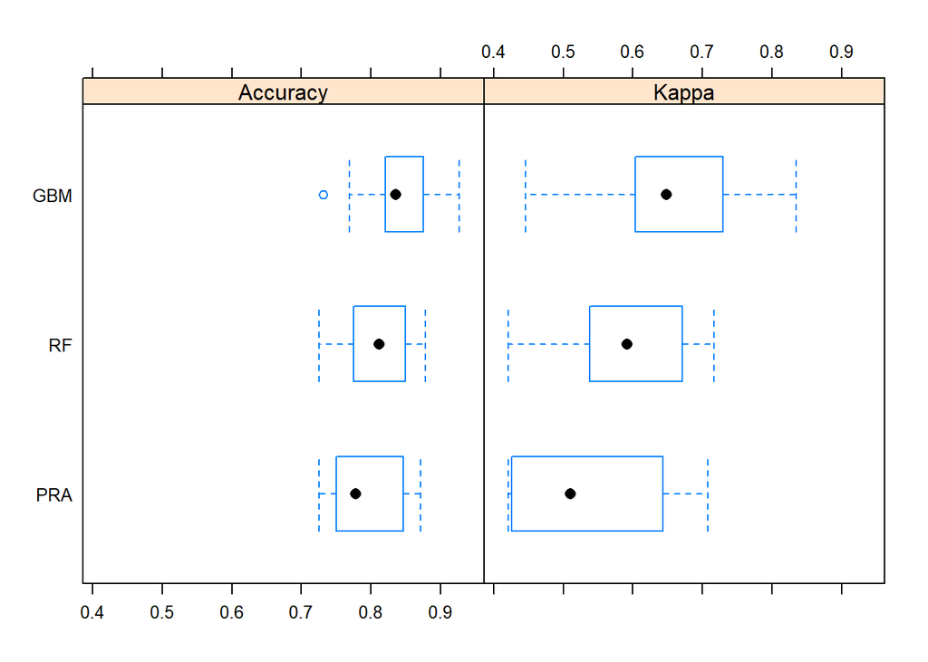

```
## glmnet
##
## 200 samples
##  59 predictor
##   2 classes: 'objective', 'subjective'
##
## No pre-processing
## Resampling: Cross-Validated (5 fold, repeated 2 times)
## Summary of sample sizes: 160, 161, 159, 160, 160, 161, ...
## Resampling results across tuning parameters:
##
##   lambda  Accuracy   Kappa
##   0.01    0.7828612  0.51437754
##   0.06    0.7927392  0.53108853
##   0.11    0.7603518  0.42950638
##   0.16    0.7148968  0.27560521
##   0.21    0.6525610  0.07651204
##   0.26    0.6399296  0.01632653
##
## Tuning parameter 'alpha' was held constant at a value of 1
## Accuracy was used to select the optimal model using the largest value.
## The final values used for the model were alpha = 1 and lambda = 0.06.
```

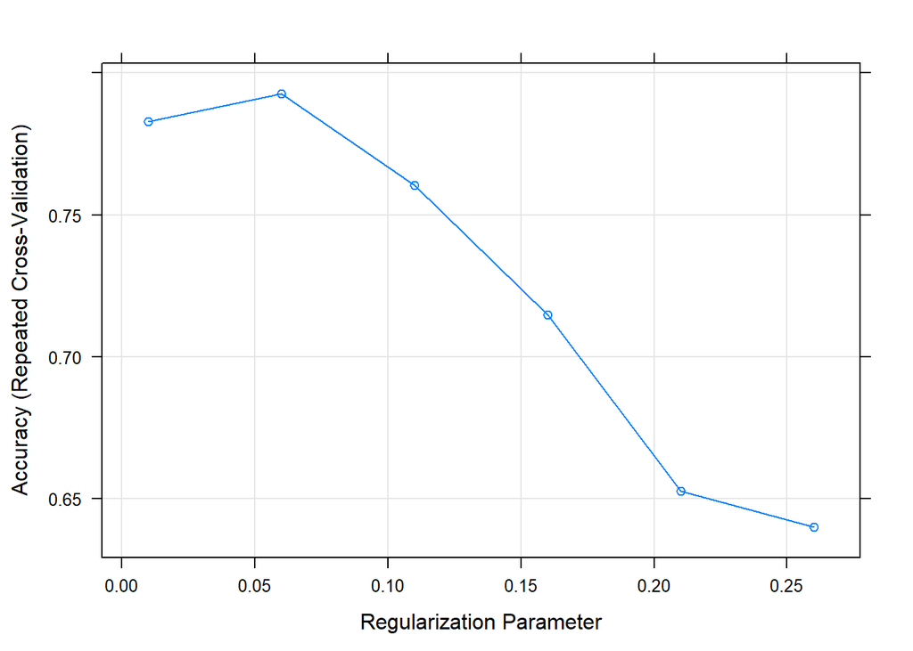

```
## Random Forest
##
## 200 samples
##  59 predictor
##   2 classes: 'objective', 'subjective'
##
## No pre-processing
## Resampling: Cross-Validated (5 fold, repeated 2 times)
## Summary of sample sizes: 159, 160, 159, 161, 161, 160, ...
## Resampling results across tuning parameters:
##
##   mtry  Accuracy   Kappa
##    2    0.8094309  0.5839960
##    5    0.8043058  0.5735372
##   10    0.8068699  0.5789729
##   25    0.7994340  0.5682048
##   50    0.8018699  0.5692354
##
## Accuracy was used to select the optimal model using the largest value.
## The final value used for the model was mtry = 2.
```

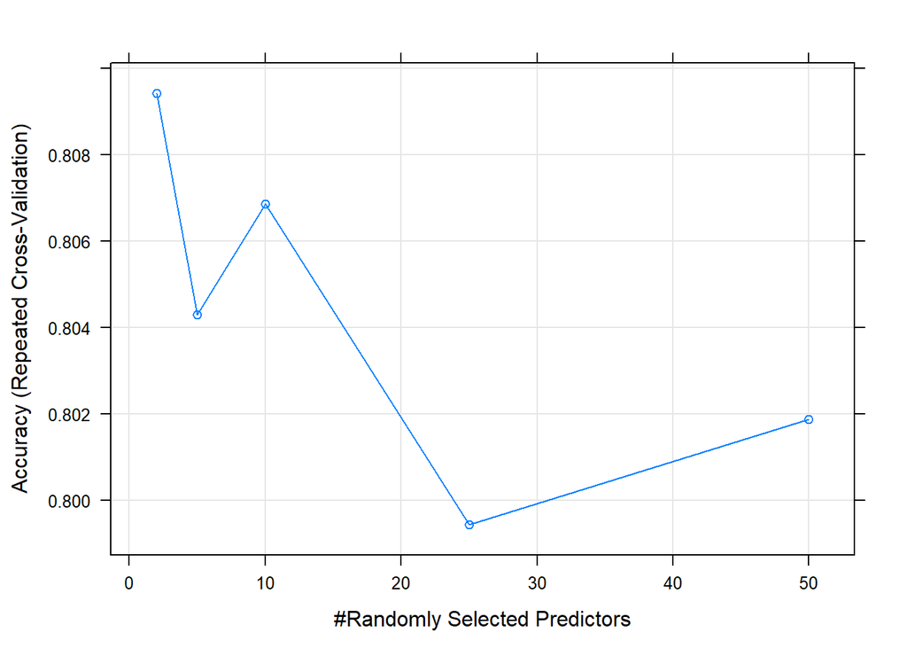

```
## Stochastic Gradient Boosting
##
## 200 samples
##  59 predictor
##   2 classes: 'objective', 'subjective'
##
## No pre-processing
## Resampling: Cross-Validated (5 fold, repeated 2 times)
## Summary of sample sizes: 161, 159, 160, 161, 159, 159, ...
## Resampling results across tuning parameters:
##
##   shrinkage  interaction.depth  n.trees  Accuracy   Kappa
##   0.05       1                   50      0.8074859  0.5756656
##   0.05       1                  100      0.8176173  0.6000112
##   0.05       1                  150      0.8147389  0.5909662
##   0.05       5                   50      0.7947936  0.5498011
##   0.05       5                  100      0.7921717  0.5476881
##   0.05       5                  150      0.7997358  0.5609818
##   0.05       9                   50      0.8076141  0.5780017
##   0.05       9                  100      0.8126751  0.5895232
##   0.05       9                  150      0.8102392  0.5859217
##   0.10       1                   50      0.8348093  0.6372418
##   0.10       1                  100      0.8303064  0.6280358
##   0.10       1                  150      0.8326845  0.6312181
##   0.10       5                   50      0.8049218  0.5691753
##   0.10       5                  100      0.7997326  0.5559156
##   0.10       5                  150      0.7971685  0.5515854
##   0.10       9                   50      0.8024218  0.5669218
##   0.10       9                  100      0.7999828  0.5586647
##   0.10       9                  150      0.7949187  0.5496682
##   0.20       1                   50      0.8146811  0.5913194
##   0.20       1                  100      0.7921717  0.5406549
##   0.20       1                  150      0.7947358  0.5470703
##   0.20       5                   50      0.7675344  0.4939319
##   0.20       5                  100      0.7750313  0.4985038
##   0.20       5                  150      0.7751595  0.4990119
##   0.20       9                   50      0.7851079  0.5207041
##   0.20       9                  100      0.7900438  0.5364840
##   0.20       9                  150      0.7799703  0.5171555
##
## Tuning parameter 'n.minobsinnode' was held constant at a value of 5
## Accuracy was used to select the optimal model using the largest value.
## The final values used for the model were n.trees = 50, interaction.depth
##  = 1, shrinkage = 0.1 and n.minobsinnode = 5.
```

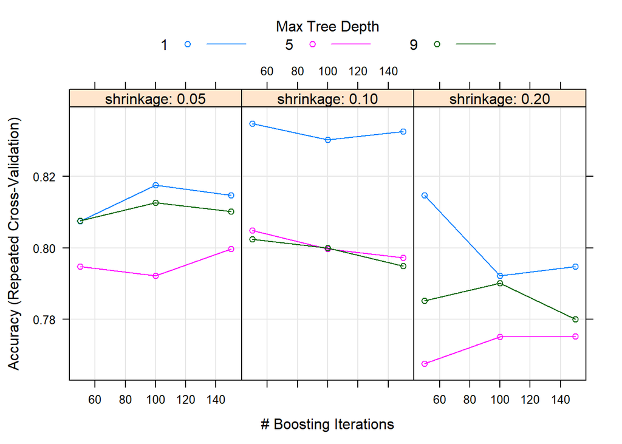

#### Fold 2

Parameter tuning results for the methods are provided below

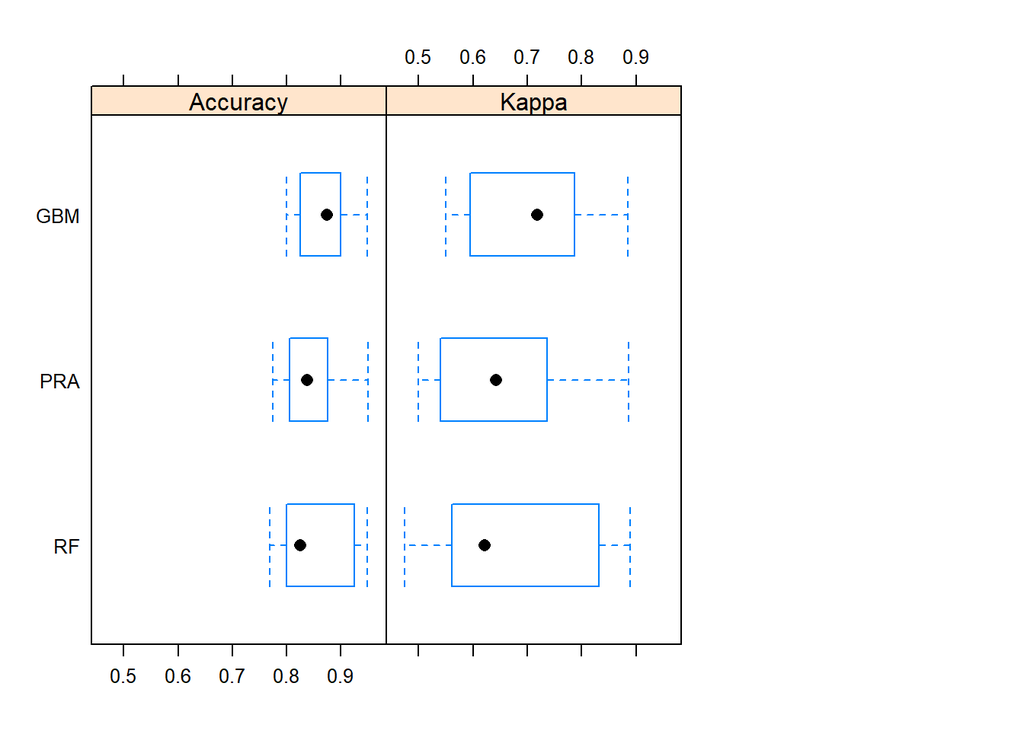

```
## glmnet
##
## 200 samples
##  59 predictor
##   2 classes: 'objective', 'subjective'
##
## No pre-processing
## Resampling: Cross-Validated (5 fold, repeated 2 times)
## Summary of sample sizes: 161, 160, 159, 160, 160, 160, ...
## Resampling results across tuning parameters:
##
##   lambda  Accuracy   Kappa
##   0.01    0.8475172  0.65916882
##   0.06    0.8325750  0.61504411
##   0.11    0.7950688  0.51472976
##   0.16    0.7575594  0.41066858
##   0.21    0.7125500  0.27088247
##   0.26    0.6399703  0.02832132
##
## Tuning parameter 'alpha' was held constant at a value of 1
## Accuracy was used to select the optimal model using the largest value.
## The final values used for the model were alpha = 1 and lambda = 0.01.
```

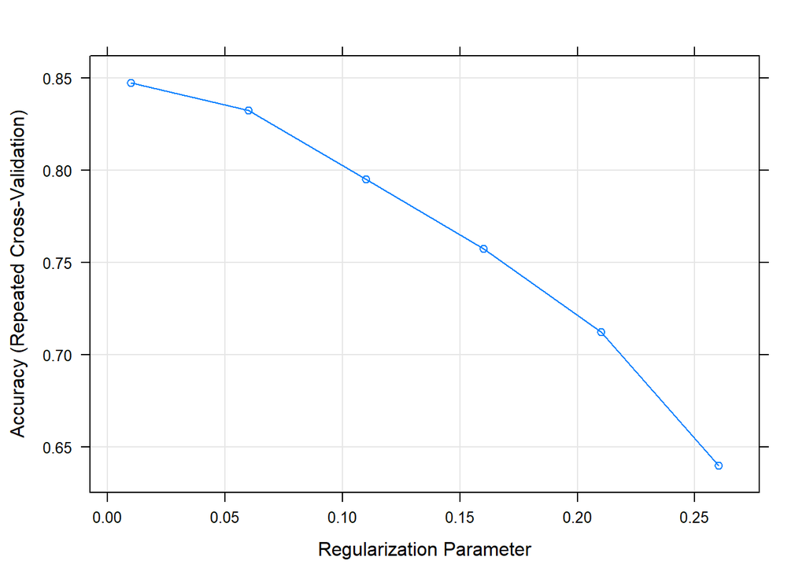

```
## Random Forest
##
## 200 samples
##  59 predictor
##   2 classes: 'objective', 'subjective'
##
## No pre-processing
## Resampling: Cross-Validated (5 fold, repeated 2 times)
## Summary of sample sizes: 159, 161, 160, 160, 160, 161, ...
## Resampling results across tuning parameters:
##
##   mtry  Accuracy   Kappa
##    2    0.8495075  0.6706855
##    5    0.8371936  0.6454856
##   10    0.8495106  0.6729460
##   25    0.8496998  0.6762292
##   50    0.8372608  0.6471046
##
## Accuracy was used to select the optimal model using the largest value.
## The final value used for the model was mtry = 25.
```

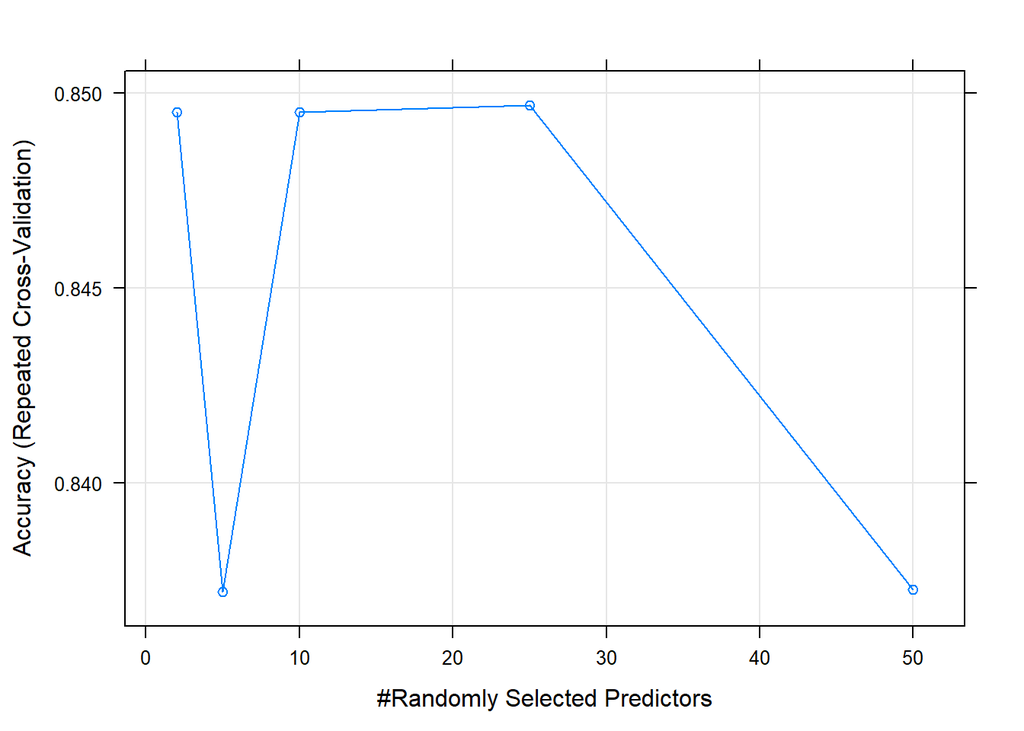

[output not shown]

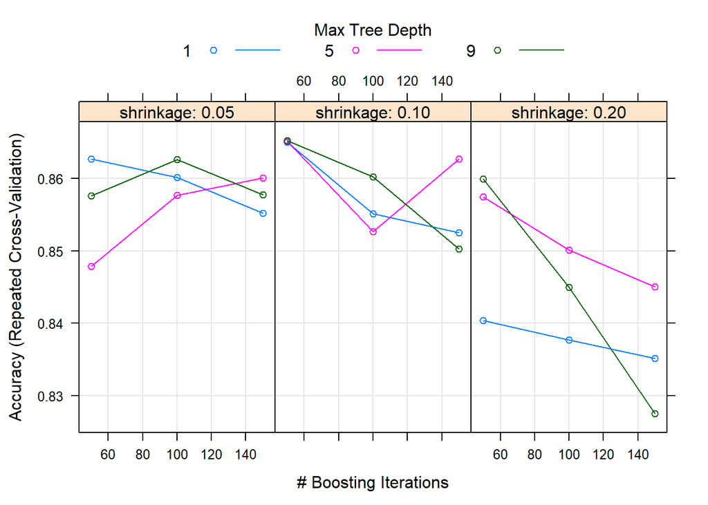

#### Fold 3

Parameter tuning results for the methods are provided below

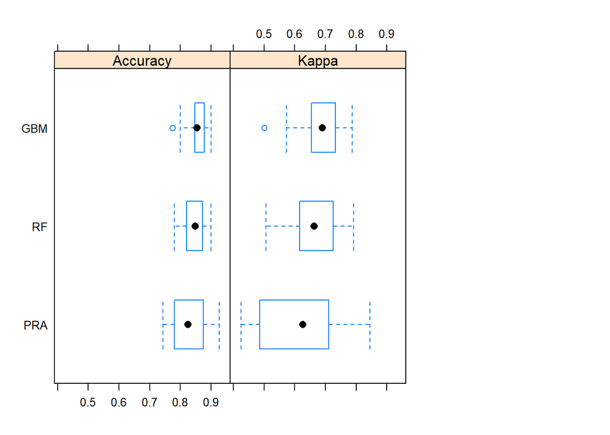

```
## glmnet
##
## 200 samples
##  59 predictor
##   2 classes: 'objective', 'subjective'
##
## No pre-processing
## Resampling: Cross-Validated (5 fold, repeated 2 times)
## Summary of sample sizes: 160, 160, 160, 161, 159, 159, ...
## Resampling results across tuning parameters:
##
##   lambda  Accuracy   Kappa
##   0.01    0.8323343  0.6221454
##   0.06    0.8075813  0.5604517
##   0.11    0.8053315  0.5427021
##   0.16    0.7702611  0.4434199
##   0.21    0.7147999  0.2663535
##   0.26    0.6574124  0.0760384
##
## Tuning parameter 'alpha' was held constant at a value of 1
## Accuracy was used to select the optimal model using the largest value.
## The final values used for the model were alpha = 1 and lambda = 0.01.
```

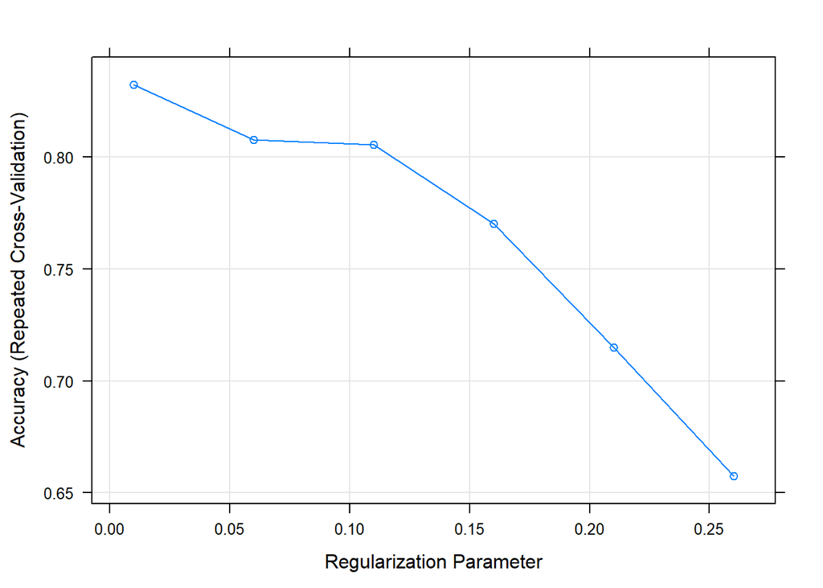

```
## Random Forest
##
## 200 samples
##  59 predictor
##   2 classes: 'objective', 'subjective'
##
## No pre-processing
## Resampling: Cross-Validated (5 fold, repeated 2 times)
## Summary of sample sizes: 160, 161, 159, 161, 159, 161, ...
## Resampling results across tuning parameters:
##
##   mtry  Accuracy   Kappa
##    2    0.8229065  0.6208441
##    5    0.8351016  0.6460920
##   10    0.8351626  0.6476884
##   25    0.8401657  0.6573836
##   50    0.8197811  0.6123743
##
## Accuracy was used to select the optimal model using the largest value.
## The final value used for the model was mtry = 25.
```

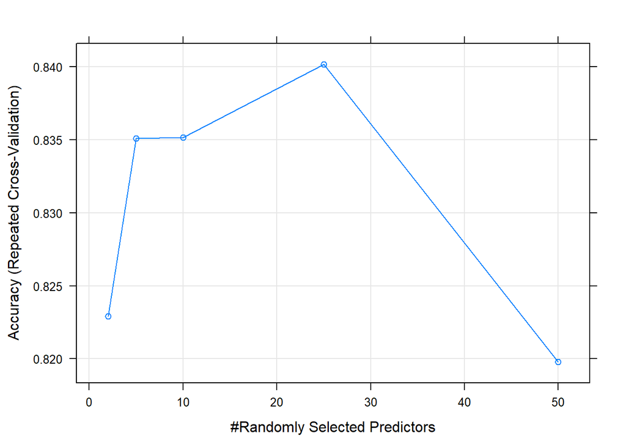

```
## Stochastic Gradient Boosting
##
## 200 samples
##  59 predictor
##   2 classes: 'objective', 'subjective'
##
## No pre-processing
## Resampling: Cross-Validated (5 fold, repeated 2 times)
## Summary of sample sizes: 160, 159, 159, 161, 161, 160, ...
## Resampling results across tuning parameters:
##
##   shrinkage  interaction.depth  n.trees  Accuracy   Kappa
##   0.05       1                   50      0.8120560  0.5905960
##   0.05       1                  100      0.8246873  0.6202169
##   0.05       1                  150      0.8448186  0.6656689
##   0.05       5                   50      0.8448796  0.6668140
##   0.05       5                  100      0.8471936  0.6711838
##   0.05       5                  150      0.8371263  0.6491425
##   0.05       9                   50      0.8397514  0.6499864
##   0.05       9                  100      0.8421936  0.6584149
##   0.05       9                  150      0.8524468  0.6803453
##   0.10       1                   50      0.8295654  0.6313725
##   0.10       1                  100      0.8374437  0.6526376
##   0.10       1                  150      0.8498796  0.6804387
##   0.10       5                   50      0.8322483  0.6392981
##   0.10       5                  100      0.8273734  0.6283701
##   0.10       5                  150      0.8373155  0.6526849
##   0.10       9                   50      0.8398796  0.6577118
##   0.10       9                  100      0.8398155  0.6539032
##   0.10       9                  150      0.8321873  0.6400065
##   0.20       1                   50      0.8372545  0.6504467
##   0.20       1                  100      0.8347452  0.6460874
##   0.20       1                  150      0.8349984  0.6472694
##   0.20       5                   50      0.8475688  0.6721688
##   0.20       5                  100      0.8400109  0.6524552
##   0.20       5                  150      0.8324406  0.6386228
##   0.20       9                   50      0.8171232  0.6102583
##   0.20       9                  100      0.8271263  0.6292029
##   0.20       9                  150      0.8295654  0.6318814
##
## Tuning parameter 'n.minobsinnode' was held constant at a value of 5
## Accuracy was used to select the optimal model using the largest value.
## The final values used for the model were n.trees = 150,
##  interaction.depth = 9, shrinkage = 0.05 and n.minobsinnode = 5.
```

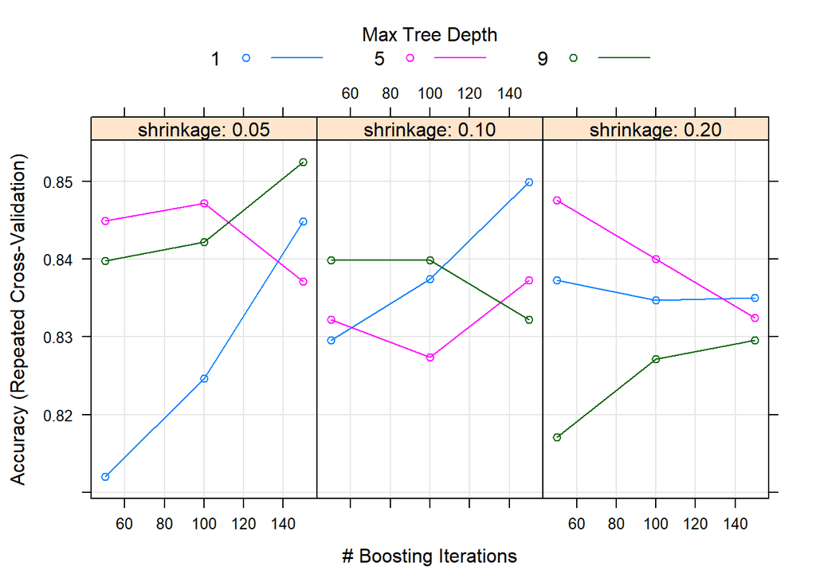

### Gesture Phase Segmentation

- Classification Problem

**Overall Test Performance of the Methods (After Parameter Tuning)**

```
##    ModelName CV_Accuracy  CV_Kappa
## 1:       PRA   0.7524492 0.6052187
## 2:        DT   0.7524492 0.6231464
## 3:        RF   0.8783751 0.8138748
## 4:       GBM   0.8884110 0.8309637
```

```
##     ModelName Fold  Accuracy     Kappa
##  1:        DT    1 0.7526882 0.6152564
##  2:        DT    2 0.7713262 0.6595017
##  3:        DT    3 0.7333333 0.5946810
##  4:       GBM    1 0.9039427 0.8540900
##  5:       GBM    2 0.8759857 0.8130040
##  6:       GBM    3 0.8853047 0.8257972
##  7:       PRA    1 0.7655914 0.6236896
##  8:       PRA    2 0.7397849 0.5836132
##  9:       PRA    3 0.7519713 0.6083534
## 10:        RF    1 0.8881720 0.8285652
## 11:        RF    2 0.8724014 0.8059133
## 12:        RF    3 0.8745520 0.8071459
```

**Class Distributions:**

```
##
##        Hold Preparation        Rest  Retraction      Stroke
##          39         163         698         191         656
```

#### Fold 1

Parameter tuning results for the methods are provided below

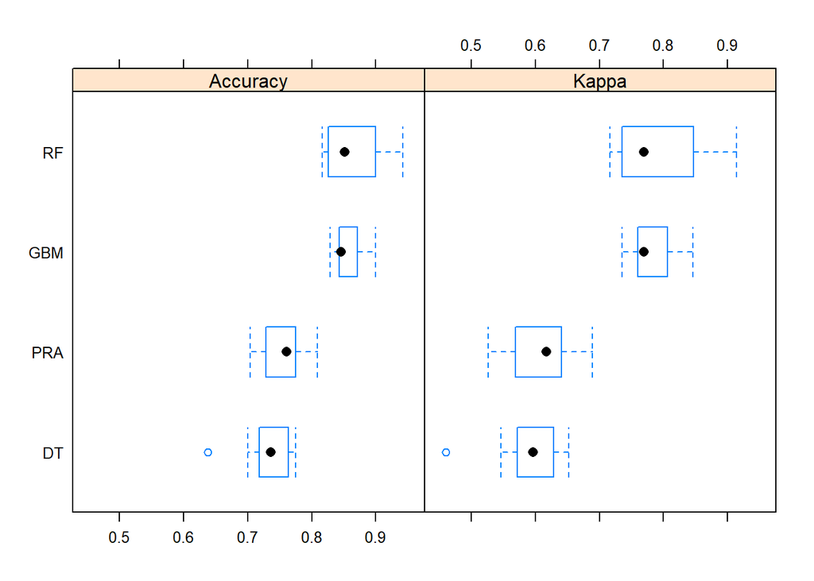

```
## glmnet
##
## 352 samples
##  18 predictor
##   5 classes: 'Hold', 'Preparation', 'Rest', 'Retraction', 'Stroke'
##
## No pre-processing
## Resampling: Cross-Validated (5 fold, repeated 2 times)
## Summary of sample sizes: 281, 281, 280, 284, 282, 281, ...
## Resampling results across tuning parameters:
##
##   lambda  Accuracy   Kappa
##   0.01    0.7558824  0.6107739
##   0.06    0.7216660  0.5467046
##   0.11    0.6918832  0.4964275
##   0.16    0.6634468  0.4491619
##   0.21    0.6251530  0.3852267
##   0.26    0.3978118  0.0000000
##
## Tuning parameter 'alpha' was held constant at a value of 1
## Accuracy was used to select the optimal model using the largest value.
## The final values used for the model were alpha = 1 and lambda = 0.01.
```

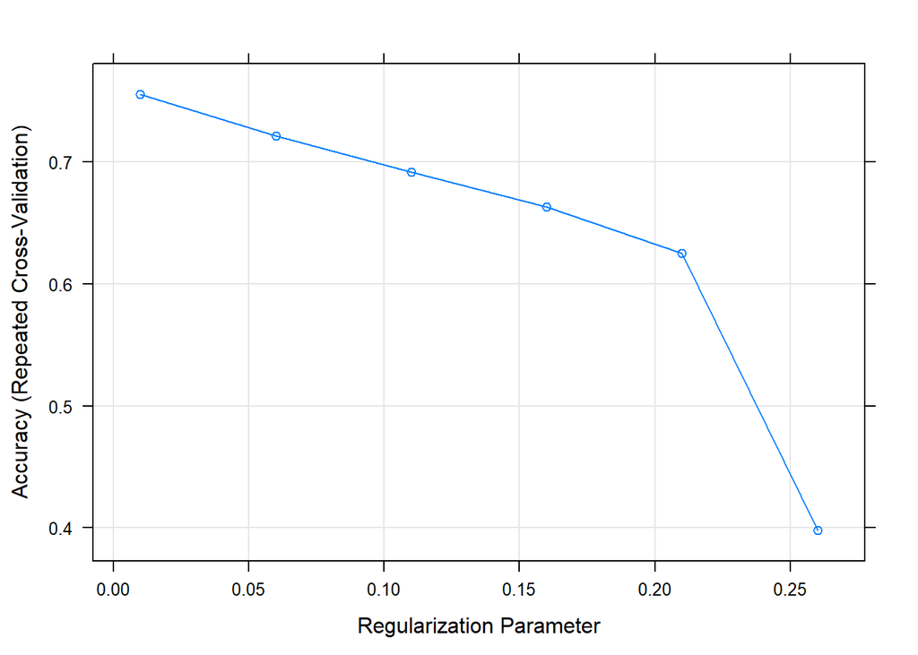

```
## CART
##
## 352 samples
##  18 predictor
##   5 classes: 'Hold', 'Preparation', 'Rest', 'Retraction', 'Stroke'
##
## No pre-processing
## Resampling: Cross-Validated (5 fold, repeated 2 times)
## Summary of sample sizes: 281, 281, 283, 282, 281, 282, ...
## Resampling results across tuning parameters:
##
##   cp    Accuracy   Kappa
##   0.01  0.7312531  0.5892073
##   0.06  0.7231049  0.5490245
##   0.11  0.6935236  0.5005228
##   0.16  0.6479046  0.4250581
##   0.21  0.6479046  0.4250581
##   0.26  0.6479046  0.4250581
##
## Accuracy was used to select the optimal model using the largest value.
## The final value used for the model was cp = 0.01.
```

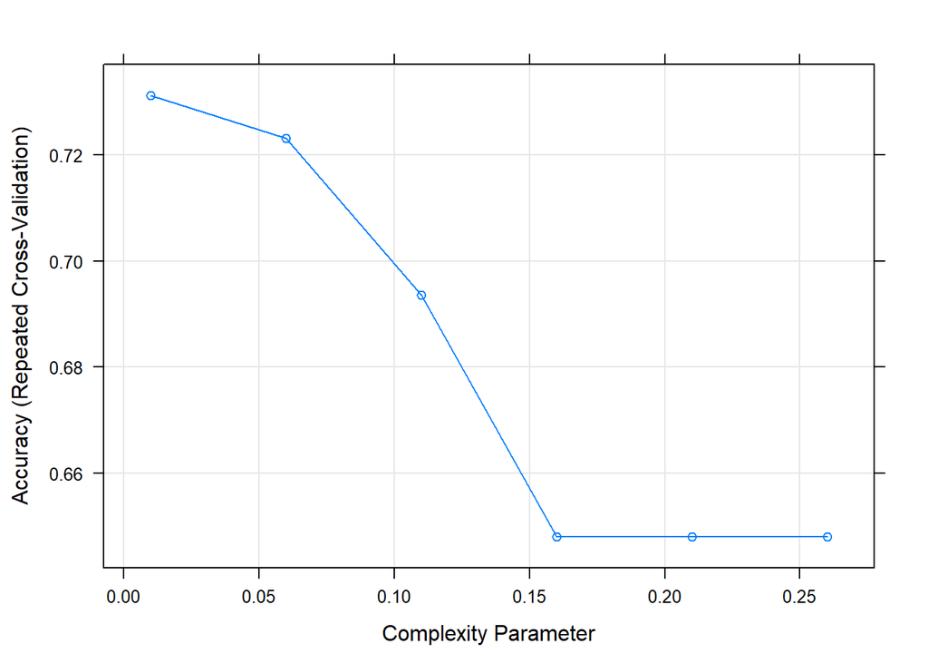

```
## Random Forest
##
## 352 samples
##  18 predictor
##   5 classes: 'Hold', 'Preparation', 'Rest', 'Retraction', 'Stroke'
##
## No pre-processing
## Resampling: Cross-Validated (5 fold, repeated 2 times)
## Summary of sample sizes: 281, 283, 282, 282, 280, 282, ...
## Resampling results across tuning parameters:
##
##   mtry  Accuracy   Kappa
##    2    0.8638667  0.7912315
##    5    0.8609480  0.7870479
##   10    0.8553740  0.7792986
##   25    0.8525980  0.7751978
##   50    0.8496592  0.7707024
##
## Accuracy was used to select the optimal model using the largest value.
## The final value used for the model was mtry = 2.
```

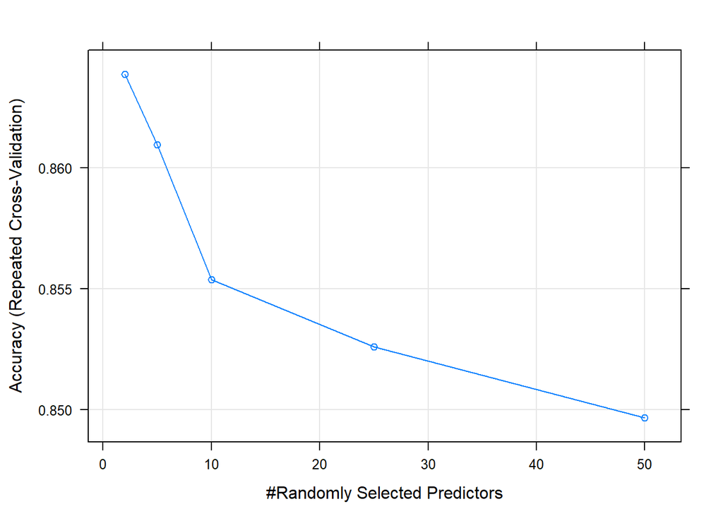

```
## Stochastic Gradient Boosting
##
## 352 samples
##  18 predictor
##   5 classes: 'Hold', 'Preparation', 'Rest', 'Retraction', 'Stroke'
##
## No pre-processing
## Resampling: Cross-Validated (5 fold, repeated 2 times)
## Summary of sample sizes: 280, 282, 282, 282, 282, 281, ...
## Resampling results across tuning parameters:
##
##   shrinkage  interaction.depth  n.trees  Accuracy   Kappa
##   0.05       1                   50      0.7642153  0.6217105
##   0.05       1                  100      0.7826671  0.6596860
##   0.05       1                  150      0.7955041  0.6840751
##   0.05       5                   50      0.8322490  0.7423844
##   0.05       5                  100      0.8408596  0.7560127
##   0.05       5                  150      0.8437167  0.7608994
##   0.05       9                   50      0.8337765  0.7441610
##   0.05       9                  100      0.8479427  0.7667323
##   0.05       9                  150      0.8394109  0.7540035
##   0.10       1                   50      0.7769534  0.6514530
##   0.10       1                  100      0.8139353  0.7153695
##   0.10       1                  150      0.8110189  0.7114958
##   0.10       5                   50      0.8351654  0.7495205
##   0.10       5                  100      0.8351654  0.7492767
##   0.10       5                  150      0.8337765  0.7471908
##   0.10       9                   50      0.8408792  0.7561908
##   0.10       9                  100      0.8494305  0.7701105
##   0.10       9                  150      0.8437162  0.7611143
##   0.20       1                   50      0.7970311  0.6911143
##   0.20       1                  100      0.8040152  0.7033364
##   0.20       1                  150      0.8210580  0.7293729
##   0.20       5                   50      0.8365733  0.7514426
##   0.20       5                  100      0.8465733  0.7665339
##   0.20       5                  150      0.8480220  0.7692564
##   0.20       9                   50      0.8508395  0.7730944
##   0.20       9                  100      0.8537167  0.7781815
##   0.20       9                  150      0.8551448  0.7797809
##
## Tuning parameter 'n.minobsinnode' was held constant at a value of 5
## Accuracy was used to select the optimal model using the largest value.
## The final values used for the model were n.trees = 150,
##  interaction.depth = 9, shrinkage = 0.2 and n.minobsinnode = 5.
```

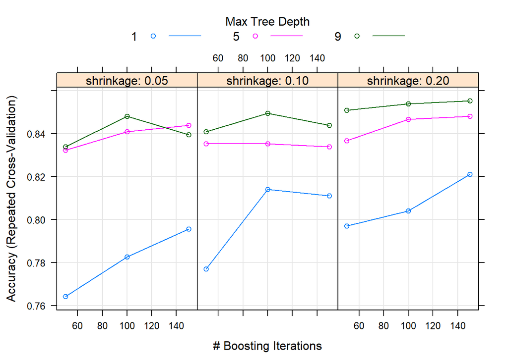

#### Fold 2

Parameter tuning results for the methods are provided below

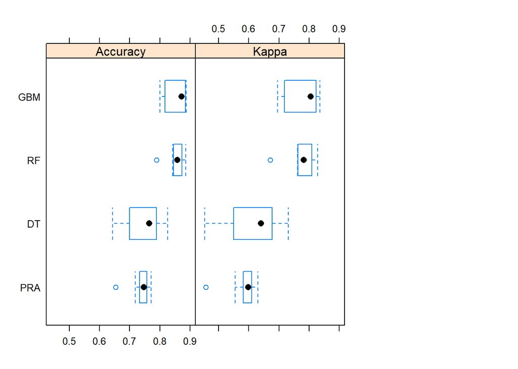

```
## glmnet
##
## 352 samples
##  18 predictor
##   5 classes: 'Hold', 'Preparation', 'Rest', 'Retraction', 'Stroke'
##
## No pre-processing
## Resampling: Cross-Validated (5 fold, repeated 2 times)
## Summary of sample sizes: 283, 282, 282, 281, 280, 281, ...
## Resampling results across tuning parameters:
##
##   lambda  Accuracy   Kappa
##   0.01    0.7374908  0.5843651
##   0.06    0.7275678  0.5561430
##   0.11    0.7118921  0.5295162
##   0.16    0.6919697  0.4964904
##   0.21    0.6211005  0.3787930
##   0.26    0.4858741  0.1498685
##
## Tuning parameter 'alpha' was held constant at a value of 1
## Accuracy was used to select the optimal model using the largest value.
## The final values used for the model were alpha = 1 and lambda = 0.01.
```

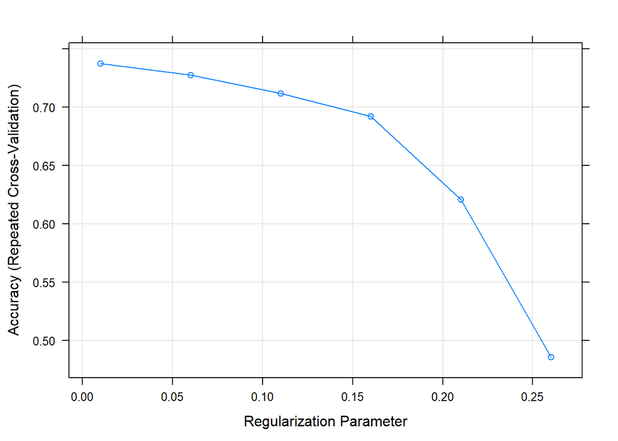

```
## CART
##
## 352 samples
##  18 predictor
##   5 classes: 'Hold', 'Preparation', 'Rest', 'Retraction', 'Stroke'
##
## No pre-processing
## Resampling: Cross-Validated (5 fold, repeated 2 times)
## Summary of sample sizes: 283, 281, 281, 281, 282, 281, ...
## Resampling results across tuning parameters:
##
##   cp    Accuracy   Kappa
##   0.01  0.7458079  0.6134798
##   0.06  0.7074963  0.5247741
##   0.11  0.7074963  0.5247741
##   0.16  0.6237072  0.3854893
##   0.21  0.6237072  0.3854893
##   0.26  0.6237072  0.3854893
##
## Accuracy was used to select the optimal model using the largest value.
## The final value used for the model was cp = 0.01.
```

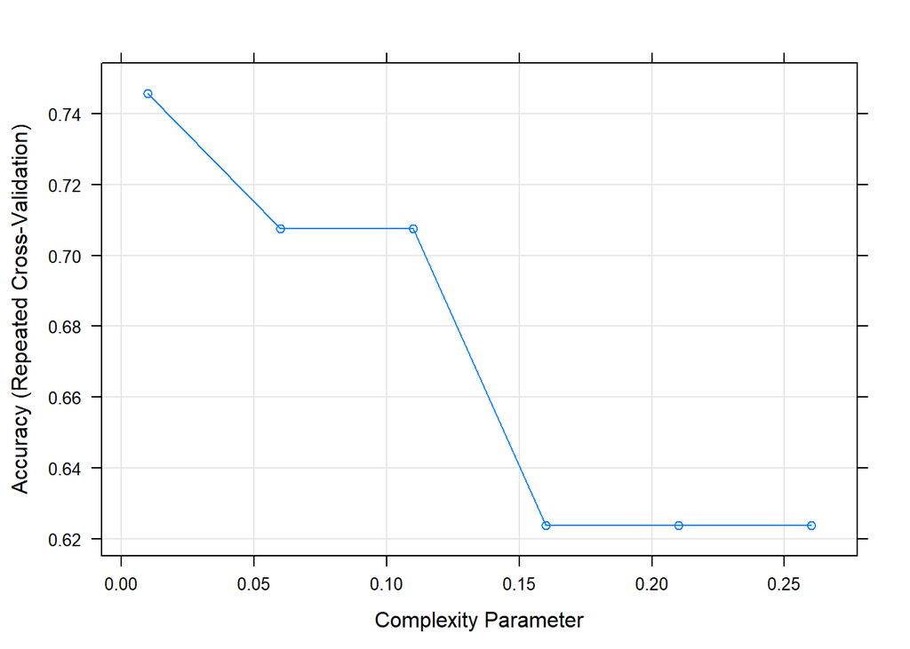

```
## Random Forest
##
## 352 samples
##  18 predictor
##   5 classes: 'Hold', 'Preparation', 'Rest', 'Retraction', 'Stroke'
##
## No pre-processing
## Resampling: Cross-Validated (5 fold, repeated 2 times)
## Summary of sample sizes: 282, 281, 282, 281, 282, 281, ...
## Resampling results across tuning parameters:
##
##   mtry  Accuracy   Kappa
##    2    0.8566197  0.7810032
##    5    0.8537626  0.7778942
##   10    0.8437827  0.7632320
##   25    0.8352716  0.7515566
##   50    0.8324145  0.7464095
##
## Accuracy was used to select the optimal model using the largest value.
## The final value used for the model was mtry = 2.
```

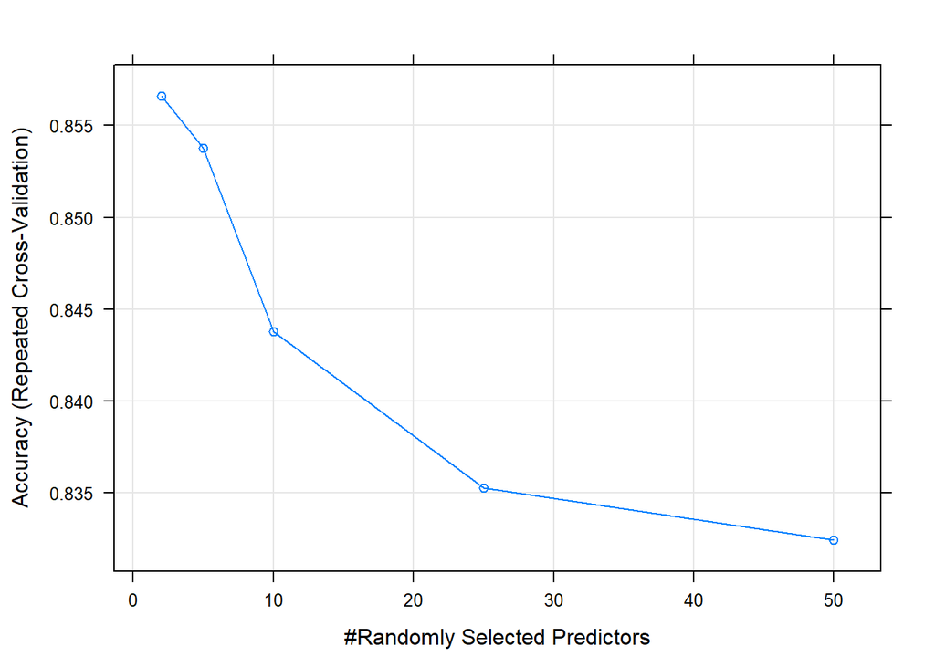

```
## Stochastic Gradient Boosting
##
## 352 samples
##  18 predictor
##   5 classes: 'Hold', 'Preparation', 'Rest', 'Retraction', 'Stroke'
##
## No pre-processing
## Resampling: Cross-Validated (5 fold, repeated 2 times)
## Summary of sample sizes: 280, 282, 282, 282, 282, 281, ...
## Resampling results across tuning parameters:
##
##   shrinkage  interaction.depth  n.trees  Accuracy   Kappa
##   0.05       1                   50      0.7642153  0.6217105
##   0.05       1                  100      0.7826671  0.6596860
##   0.05       1                  150      0.7955041  0.6840751
##   0.05       5                   50      0.8322490  0.7423844
##   0.05       5                  100      0.8408596  0.7560127
##   0.05       5                  150      0.8437167  0.7608994
##   0.05       9                   50      0.8337765  0.7441610
##   0.05       9                  100      0.8479427  0.7667323
##   0.05       9                  150      0.8394109  0.7540035
##   0.10       1                   50      0.7769534  0.6514530
##   0.10       1                  100      0.8139353  0.7153695
##   0.10       1                  150      0.8110189  0.7114958
##   0.10       5                   50      0.8351654  0.7495205
##   0.10       5                  100      0.8351654  0.7492767
##   0.10       5                  150      0.8337765  0.7471908
##   0.10       9                   50      0.8408792  0.7561908
##   0.10       9                  100      0.8494305  0.7701105
##   0.10       9                  150      0.8437162  0.7611143
##   0.20       1                   50      0.7970311  0.6911143
##   0.20       1                  100      0.8040152  0.7033364
##   0.20       1                  150      0.8210580  0.7293729
##   0.20       5                   50      0.8365733  0.7514426
##   0.20       5                  100      0.8465733  0.7665339
##   0.20       5                  150      0.8480220  0.7692564
##   0.20       9                   50      0.8508395  0.7730944
##   0.20       9                  100      0.8537167  0.7781815
##   0.20       9                  150      0.8551448  0.7797809
##
## Tuning parameter 'n.minobsinnode' was held constant at a value of 5
## Accuracy was used to select the optimal model using the largest value.
## The final values used for the model were n.trees = 150,
##  interaction.depth = 9, shrinkage = 0.2 and n.minobsinnode = 5.
```

[figure not shown]

#### Fold 3

Parameter tuning results for the methods are provided below

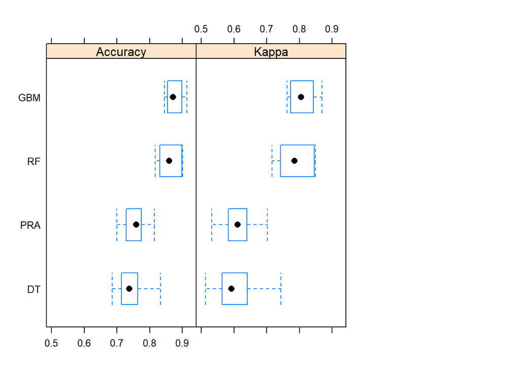

```
## glmnet
##
## 352 samples
##  18 predictor
##   5 classes: 'Hold', 'Preparation', 'Rest', 'Retraction', 'Stroke'
##
## No pre-processing
## Resampling: Cross-Validated (5 fold, repeated 2 times)
## Summary of sample sizes: 282, 282, 282, 281, 281, 281, ...
## Resampling results across tuning parameters:
##
##   lambda  Accuracy   Kappa
##   0.01    0.7542656  0.6109331
##   0.06    0.7329175  0.5646950
##   0.11    0.6959155  0.5030068
##   0.16    0.6760161  0.4697061
##   0.21    0.6306237  0.3943024
##   0.26    0.4758149  0.1328027
##
## Tuning parameter 'alpha' was held constant at a value of 1
## Accuracy was used to select the optimal model using the largest value.
## The final values used for the model were alpha = 1 and lambda = 0.01.
```

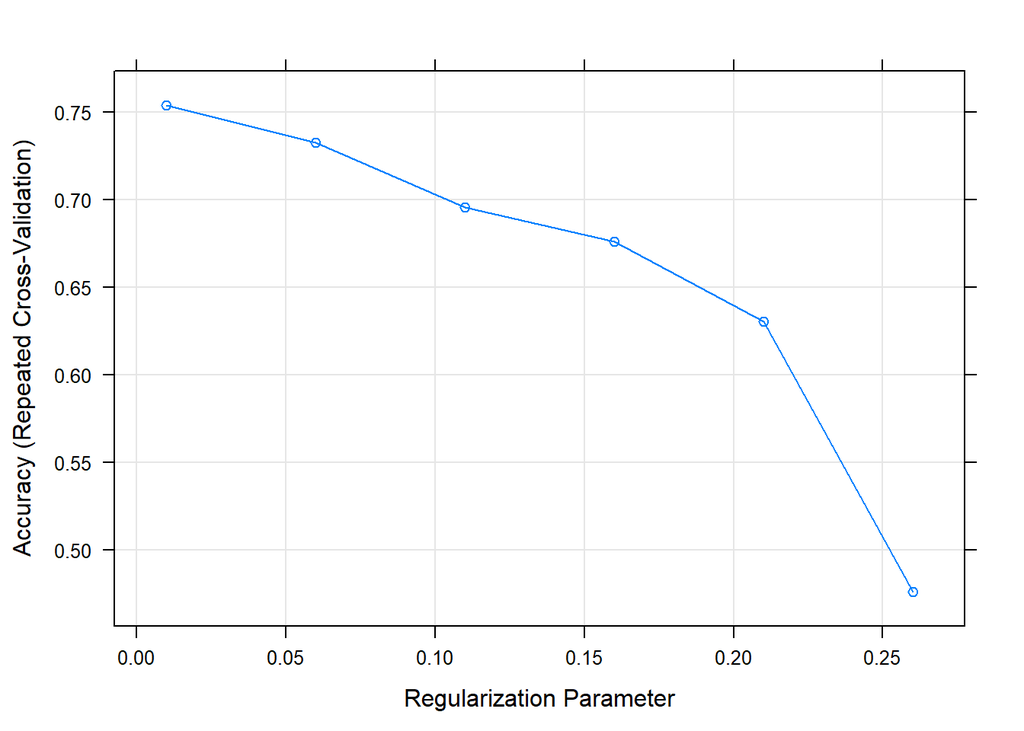

```
## CART
##
## 352 samples
##  18 predictor
##   5 classes: 'Hold', 'Preparation', 'Rest', 'Retraction', 'Stroke'
##
## No pre-processing
## Resampling: Cross-Validated (5 fold, repeated 2 times)
## Summary of sample sizes: 281, 282, 282, 282, 281, 280, ...
## Resampling results across tuning parameters:
##
##   cp    Accuracy   Kappa
##   0.01  0.7455610  0.6087765
##   0.06  0.7285894  0.5578544
##   0.11  0.6804307  0.4778530
##   0.16  0.6790022  0.4752311
##   0.21  0.6790022  0.4752311
##   0.26  0.6790022  0.4752311
##
## Accuracy was used to select the optimal model using the largest value.
## The final value used for the model was cp = 0.01.
```

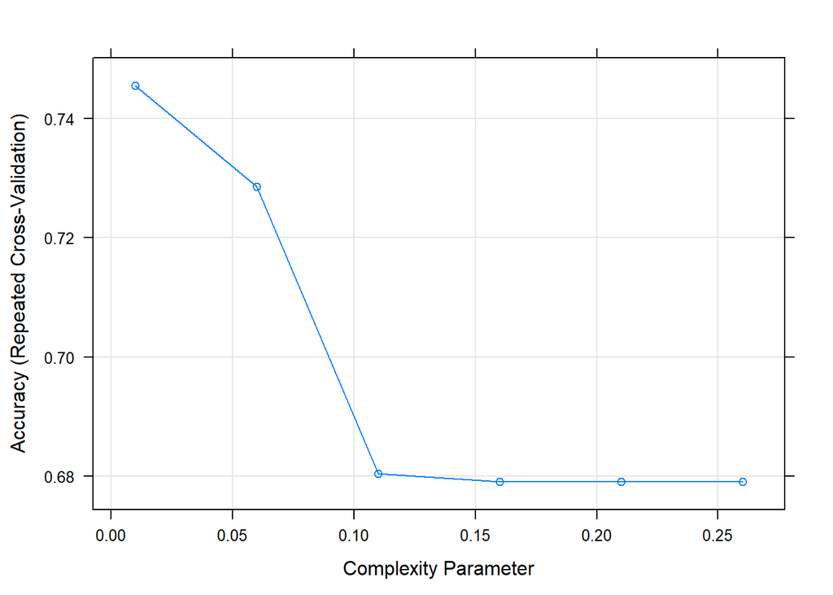

```
## Random Forest
##
## 352 samples
##  18 predictor
##   5 classes: 'Hold', 'Preparation', 'Rest', 'Retraction', 'Stroke'
##
## No pre-processing
## Resampling: Cross-Validated (5 fold, repeated 2 times)
## Summary of sample sizes: 282, 283, 280, 282, 281, 281, ...
## Resampling results across tuning parameters:
##
##   mtry  Accuracy   Kappa
##    2    0.8608958  0.7859252
##    5    0.8538518  0.7771032
##   10    0.8496460  0.7717137
##   25    0.8382974  0.7561753
##   50    0.8354403  0.7516762
##
## Accuracy was used to select the optimal model using the largest value.
## The final value used for the model was mtry = 2.
```

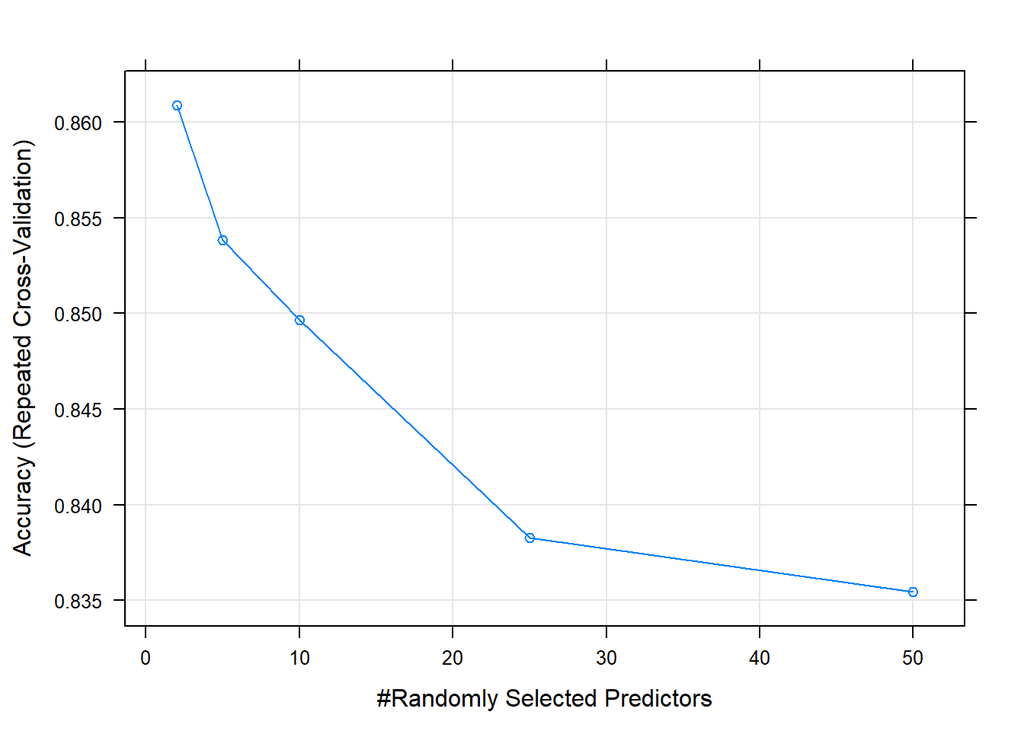

```
## Stochastic Gradient Boosting
##
## 352 samples
##  18 predictor
##   5 classes: 'Hold', 'Preparation', 'Rest', 'Retraction', 'Stroke'
##
## No pre-processing
## Resampling: Cross-Validated (5 fold, repeated 2 times)
## Summary of sample sizes: 281, 283, 282, 282, 280, 280, ...
## Resampling results across tuning parameters:
##
##   shrinkage  interaction.depth  n.trees  Accuracy   Kappa
##   0.05       1                   50      0.7712926  0.6339647
##   0.05       1                  100      0.7770667  0.6499835
##   0.05       1                  150      0.7857198  0.6653158
##   0.05       5                   50      0.8269741  0.7313630
##   0.05       5                  100      0.8483245  0.7670260
##   0.05       5                  150      0.8566969  0.7803489
##   0.05       9                   50      0.8310395  0.7380597
##   0.05       9                  100      0.8481445  0.7660722
##   0.05       9                  150      0.8608826  0.7869553
##   0.10       1                   50      0.7841503  0.6602577
##   0.10       1                  100      0.7955202  0.6835354
##   0.10       1                  150      0.8083992  0.7057764
##   0.10       5                   50      0.8524106  0.7736584
##   0.10       5                  100      0.8625314  0.7909195
##   0.10       5                  150      0.8666993  0.7981410
##   0.10       9                   50      0.8411414  0.7559698
##   0.10       9                  100      0.8538795  0.7761893
##   0.10       9                  150      0.8552080  0.7793033
##   0.20       1                   50      0.7929052  0.6803626
##   0.20       1                  100      0.8099491  0.7100447
##   0.20       1                  150      0.8268723  0.7371144
##   0.20       5                   50      0.8525101  0.7741796
##   0.20       5                  100      0.8694759  0.8019692
##   0.20       5                  150      0.8751103  0.8104997
##   0.20       9                   50      0.8652114  0.7946521
##   0.20       9                  100      0.8695972  0.8023841
##   0.20       9                  150      0.8567988  0.7832656
##
## Tuning parameter 'n.minobsinnode' was held constant at a value of 5
## Accuracy was used to select the optimal model using the largest value.
## The final values used for the model were n.trees = 150,
##  interaction.depth = 5, shrinkage = 0.2 and n.minobsinnode = 5.
```

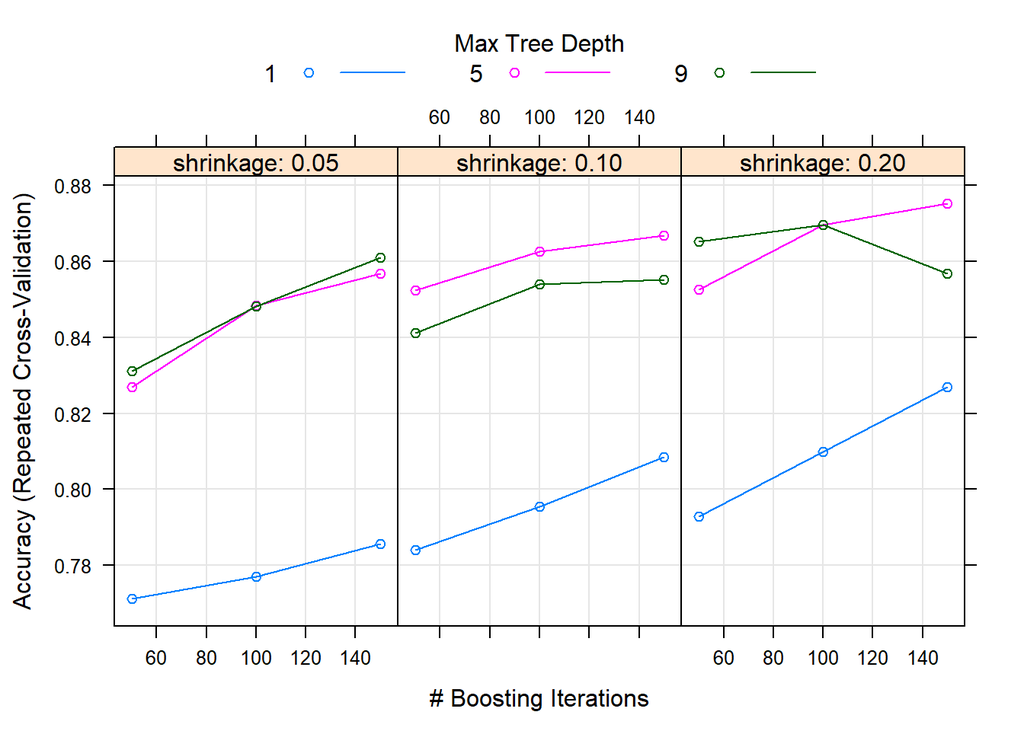

## Summary

1. In most of the cases cross-validation error rates are consistent with the test error rates. However we can observe fluctuation in cross-validation error rates, actually that is the reason we apply cross-validation - to obtain a more robust error rate for a method - while comparing the performances of different models as well as determining hyper parameter. (Individual error rates and the confidence interval for each case w.r.t folds & resamplings are provided above)
2. For the used data sets and the provided settings, we can conclude that Stochastic Gradient Boosting performs better than the other methods for classification problems. On the other hand, Random Forest provides the best result on the regression problem.
3. test errors are higher observed to be higher than the training errors. For the most of the cases the difference is not big so we can conclude that the methods has a stable performances on the data sets.

Source codes are provided in the appendix

## Appendix

### Student Performance

```r
rm(list = ls())
setwd("G:/My Drive/Z.ME/Boun/IE 582/HW-4/DataSets")

library(data.table)
library(caret)

# Load Data
data <- fread(file = "student/student-por.csv")

# Run Parameters
IsRegression <-1

# Prepare Data
data <- data[,-c("G1", "G2"), with = FALSE]
str(data)
dim(data)

# Rename Dependent Variable
names(data)[names(data) == "G3"] <- "DependentVariable"
table(data$DependentVariable)


if (IsRegression == 0) {

  data$DependentVariable <- as.factor(data$DependentVariable)

}

# Create Folds for robust test performance
minTestObsFreq <- max(200/dim(data)[1], 0.2)
nFold <- 3

# Take stratification into consideration while splitting
folds <- createDataPartition(data$DependentVariable, p = minTestObsFreq, list = FALSE, times = nFold)
head(folds)


# Experiment
modelObjects <- list()
testPerformances <- data.table()


for (f in c(1:nFold)) {

  # Set Random Seed to ensure the resamplings will be the same for each model
  set.seed(7 * f)

  # Create Test/Train Data sets
  training <- data[folds[,f],]
  testing <- data[-folds[,f],]

  # Define Train CV and Resampling parametes
  fitControl <- trainControl( method = "repeatedcv",
                              ## 5-fold CV
                              number = 5,
                              ## repeated 2 times
                              repeats = 2)

  try({
  #### PRA #####
  print("PRA")
  time <- Sys.time()

  # Parameter selection for PRA model
  praGrid <-  expand.grid(alpha = 1, # To use lasso penalty
                          lambda = seq(0.01,0.3,0.05))


  # PRA Train and Parameter Tuning
  praFit <- train(DependentVariable ~ ., data = training,
                  method = "glmnet",
                  trControl = fitControl,
                  tuneGrid = praGrid)

  modelObjects[["PRA"]][[paste0("Fold", f)]] <- praFit

  praFit

  plot(praFit)

  # Predictions for the fold
  Prediction <- predict.train(praFit, newdata = testing)

  # Test Metrics
  testResult <- postResample(pred = Prediction, obs = testing$DependentVariable)

  # Save the test metrics
  testPerformances <- rbind(testPerformances, cbind(data.table(ModelName = "PRA", Fold = f, Time = (Sys.time() - time)), data.table(t(testResult))))


  })

  #### DT #####
  print("DT")
  time <- Sys.time()

  # Parameter selection for DT model
  dtGrid <-  expand.grid(cp = seq(0.01,0.3,0.05))


  # DT Train and Parameter Tuning
  dtFit <- train(DependentVariable ~ ., data = training,
                 method = "rpart",
                 trControl = fitControl,
                 tuneGrid = dtGrid)

  modelObjects[["DT"]][[paste0("Fold", f)]] <- dtFit

  dtFit

  plot(dtFit)

  # Predictions for the fold
  Prediction <- predict.train(dtFit, newdata = testing)

  # Test Metrics
  testResult <- postResample(pred = Prediction, obs = testing$DependentVariable)

  # Save the test metrics
  testPerformances <- rbind(testPerformances, cbind(data.table(ModelName = "DT", Fold = f, Time = (Sys.time() - time)), data.table(t(testResult))))




  #### SVM #####
  print("SVM")
  time <- Sys.time()

  if (IsRegression == 5) {

    # Parameter selection for SVM model
    # svmPolyGrid <-  expand.grid()


    # SVM Train and Parameter Tuning
    svmPolyFit <- train(DependentVariable ~ ., data = training,
                        method = "lssvmPoly",
                        trControl = fitControl,
                        # preProc = c("center", "scale"),
                        tuneLength = 8)

    modelObjects[["SVMPoly"]][[paste0("Fold", f)]] <- svmPolyFit

    svmPolyFit

    plot(svmPolyFit)

    # Predictions for the fold
    Prediction <- predict.train(svmPolyFit, newdata = testing)

    # Test Metrics
    testResult <- postResample(pred = Prediction, obs = testing$DependentVariable)

    # Save the test metrics
    testPerformances <- rbind(testPerformances, cbind(data.table(ModelName = "SVMPoly", Fold = f, Time = (Sys.time() - time)), data.table(t(testResult))))



    # Parameter selection for SVM model
    # svmRadialGrid <-  expand.grid()


    # SVM Train and Parameter Tuning
    svmRadialFit <- train(DependentVariable ~ ., data = training,
                        method = "lssvmRadial",
                        trControl = fitControl,
                        # preProc = c("center", "scale"),
                        tuneLength = 8)

    modelObjects[["SVMRadial"]][[paste0("Fold", f)]] <- svmRadialFit

    svmRadialFit

    plot(svmRadialFit)

    # Predictions for the fold
    Prediction <- predict.train(svmRadialFit, newdata = testing)

    # Test Metrics
    testResult <- postResample(pred = Prediction, obs = testing$DependentVariable)

    # Save the test metrics
    testPerformances <- rbind(testPerformances, cbind(data.table(ModelName = "SVMRadial", Fold = f, Time = (Sys.time() - time)), data.table(t(testResult))))


  }



  #### RF #####
  print("RF")
  time <- Sys.time()

  # Parameter selection for GBM model
  rfGrid <-  expand.grid(mtry = c(2, 5, 10, 25, 50))

  # GBM Train and Parameter Tuning
  rfFit <- train( DependentVariable ~ ., data = training,
                   method = "rf",
                   trControl = fitControl,
                   tuneGrid = rfGrid,
                   verbose = FALSE)


  modelObjects[["RF"]][[paste0("Fold", f)]] <- rfFit

  rfFit

  plot(rfFit)

  # Predictions for the fold
  Prediction <- predict.train(rfFit, newdata = testing)

  # Test Metrics
  testResult <- postResample(pred = Prediction, obs = testing$DependentVariable)

  # Save the test metrics
  testPerformances <- rbind(testPerformances, cbind(data.table(ModelName = "RF", Fold = f, Time = (Sys.time() - time)), data.table(t(testResult))))





  #### SGB #####
  print("SGB")
  time <- Sys.time()

  # Parameter selection for GBM model
  gbmGrid <-  expand.grid(interaction.depth = c(1, 5, 9),
                          n.trees = c(50, 100, 150),
                          shrinkage = c(0.05, 0.1, 0.2),
                          n.minobsinnode = 5)

  # GBM Train and Parameter Tuning
  gbmFit <- train( DependentVariable ~ ., data = training,
                   method = "gbm",
                   trControl = fitControl,
                   tuneGrid = gbmGrid,
                   verbose = FALSE)


  modelObjects[["GBM"]][[paste0("Fold", f)]] <- gbmFit

  gbmFit

  plot(gbmFit)

  # Predictions for the fold
  Prediction <- predict.train(gbmFit, newdata = testing)

  # Test Metrics
  testResult <- postResample(pred = Prediction, obs = testing$DependentVariable)

  # Save the test metrics
  testPerformances <- rbind(testPerformances, cbind(data.table(ModelName = "GBM", Fold = f, Time = (Sys.time() - time)), data.table(t(testResult))))


}

save.image(file = "G:\\My Drive\\Z.ME\\Boun\\IE 582\\HW-4\\Data1.RData")
```

### Breast Cancer Wisconsin

```r
rm(list = ls())
setwd("G:/My Drive/Z.ME/Boun/IE 582/HW-4/DataSets")

library(data.table)
library(caret)

# Load Data
data <- fread(file = "wdbc.data")

# Run Parameters
IsRegression <- 0

# Prepare Data
data <- data[,-c("V1"), with = FALSE]
str(data)
dim(data)

# Rename Dependent Variable
names(data)[names(data) == "V2"] <- "DependentVariable"
table(data$DependentVariable)


if (IsRegression == 0) {

  data$DependentVariable <- as.factor(data$DependentVariable)

}

# Create Folds for robust test performance
minTestObsFreq <- max(200/dim(data)[1], 0.2)
nFold <- 3

# Take stratification into consideration while splitting
folds <- createDataPartition(data$DependentVariable, p = minTestObsFreq, list = FALSE, times = nFold)
head(folds)


# Experiment
modelObjects <- list()
testPerformances <- data.table()


for (f in c(1:nFold)) {

  # Set Random Seed to ensure the resamplings will be the same for each model
  set.seed(7 * f)

  # Create Test/Train Data sets
  training <- data[folds[,f],]
  testing <- data[-folds[,f],]

  # Define Train CV and Resampling parametes
  fitControl <- trainControl( method = "repeatedcv",
                              ## 5-fold CV
                              number = 5,
                              ## repeated 2 times
                              repeats = 2)

  try({
  #### PRA #####
  print("PRA")
  time <- Sys.time()

  # Parameter selection for PRA model
  praGrid <-  expand.grid(alpha = 1, # To use lasso penalty
                          lambda = seq(0.01,0.3,0.05))


  # PRA Train and Parameter Tuning
  praFit <- train(DependentVariable ~ ., data = training,
                  method = "glmnet",
                  trControl = fitControl,
                  tuneGrid = praGrid)

  modelObjects[["PRA"]][[paste0("Fold", f)]] <- praFit

  praFit

  plot(praFit)

  # Predictions for the fold
  Prediction <- predict.train(praFit, newdata = testing)

  # Test Metrics
  testResult <- postResample(pred = Prediction, obs = testing$DependentVariable)

  # Save the test metrics
  testPerformances <- rbind(testPerformances, cbind(data.table(ModelName = "PRA", Fold = f, Time = (Sys.time() - time)), data.table(t(testResult))))


  })

  #### DT #####
  print("DT")
  time <- Sys.time()

  # Parameter selection for DT model
  dtGrid <-  expand.grid(cp = seq(0.01,0.3,0.05))


  # DT Train and Parameter Tuning
  dtFit <- train(DependentVariable ~ ., data = training,
                 method = "rpart",
                 trControl = fitControl,
                 tuneGrid = dtGrid)

  modelObjects[["DT"]][[paste0("Fold", f)]] <- dtFit

  dtFit

  plot(dtFit)

  # Predictions for the fold
  Prediction <- predict.train(dtFit, newdata = testing)

  # Test Metrics
  testResult <- postResample(pred = Prediction, obs = testing$DependentVariable)

  # Save the test metrics
  testPerformances <- rbind(testPerformances, cbind(data.table(ModelName = "DT", Fold = f, Time = (Sys.time() - time)), data.table(t(testResult))))




  #### SVM #####
  print("SVM")
  time <- Sys.time()

  if (IsRegression == 5) {

    # Parameter selection for SVM model
    # svmPolyGrid <-  expand.grid()


    # SVM Train and Parameter Tuning
    svmPolyFit <- train(DependentVariable ~ ., data = training,
                        method = "lssvmPoly",
                        trControl = fitControl,
                        # preProc = c("center", "scale"),
                        tuneLength = 8)

    modelObjects[["SVMPoly"]][[paste0("Fold", f)]] <- svmPolyFit

    svmPolyFit

    plot(svmPolyFit)

    # Predictions for the fold
    Prediction <- predict.train(svmPolyFit, newdata = testing)

    # Test Metrics
    testResult <- postResample(pred = Prediction, obs = testing$DependentVariable)

    # Save the test metrics
    testPerformances <- rbind(testPerformances, cbind(data.table(ModelName = "SVMPoly", Fold = f, Time = (Sys.time() - time)), data.table(t(testResult))))



    # Parameter selection for SVM model
    # svmRadialGrid <-  expand.grid()


    # SVM Train and Parameter Tuning
    svmRadialFit <- train(DependentVariable ~ ., data = training,
                        method = "lssvmRadial",
                        trControl = fitControl,
                        # preProc = c("center", "scale"),
                        tuneLength = 8)

    modelObjects[["SVMRadial"]][[paste0("Fold", f)]] <- svmRadialFit

    svmRadialFit

    plot(svmRadialFit)

    # Predictions for the fold
    Prediction <- predict.train(svmRadialFit, newdata = testing)

    # Test Metrics
    testResult <- postResample(pred = Prediction, obs = testing$DependentVariable)

    # Save the test metrics
    testPerformances <- rbind(testPerformances, cbind(data.table(ModelName = "SVMRadial", Fold = f, Time = (Sys.time() - time)), data.table(t(testResult))))


  }



  #### RF #####
  print("RF")
  time <- Sys.time()

  # Parameter selection for GBM model
  rfGrid <-  expand.grid(mtry = c(2, 5, 10, 25, 50))

  # GBM Train and Parameter Tuning
  rfFit <- train( DependentVariable ~ ., data = training,
                   method = "rf",
                   trControl = fitControl,
                   tuneGrid = rfGrid,
                   verbose = FALSE)


  modelObjects[["RF"]][[paste0("Fold", f)]] <- rfFit

  rfFit

  plot(rfFit)

  # Predictions for the fold
  Prediction <- predict.train(rfFit, newdata = testing)

  # Test Metrics
  testResult <- postResample(pred = Prediction, obs = testing$DependentVariable)

  # Save the test metrics
  testPerformances <- rbind(testPerformances, cbind(data.table(ModelName = "RF", Fold = f, Time = (Sys.time() - time)), data.table(t(testResult))))





  #### SGB #####
  print("SGB")
  time <- Sys.time()

  # Parameter selection for GBM model
  gbmGrid <-  expand.grid(interaction.depth = c(1, 5, 9),
                          n.trees = c(50, 100, 150),
                          shrinkage = c(0.05, 0.1, 0.2),
                          n.minobsinnode = 5)

  # GBM Train and Parameter Tuning
  gbmFit <- train( DependentVariable ~ ., data = training,
                   method = "gbm",
                   trControl = fitControl,
                   tuneGrid = gbmGrid,
                   verbose = FALSE)


  modelObjects[["GBM"]][[paste0("Fold", f)]] <- gbmFit

  gbmFit

  plot(gbmFit)

  # Predictions for the fold
  Prediction <- predict.train(gbmFit, newdata = testing)

  # Test Metrics
  testResult <- postResample(pred = Prediction, obs = testing$DependentVariable)

  # Save the test metrics
  testPerformances <- rbind(testPerformances, cbind(data.table(ModelName = "GBM", Fold = f, Time = (Sys.time() - time)), data.table(t(testResult))))


}

save.image(file = "G:\\My Drive\\Z.ME\\Boun\\IE 582\\HW-4\\Data2.RData")
```

### Sports Articles for Objectivity Analysis

```r
rm(list = ls())
setwd("G:/My Drive/Z.ME/Boun/IE 582/HW-4/DataSets")

library(data.table)
library(caret)

# Load Data
data <- fread(file = "SportsArticles/features.csv", header = T)

# Run Parameters
IsRegression <- 0

# Prepare Data
data <- data[, -c("TextID", "URL"), with = F]
str(data)
dim(data)


# Rename Dependent Variable
names(data)[names(data) == "Label"] <- "DependentVariable"
table(data$DependentVariable)

if (IsRegression == 0) {

  data$DependentVariable <- as.factor(data$DependentVariable)

}

# Create Folds for robust test performance
minTestObsFreq <- max(200/dim(data)[1], 0.2)
nFold <- 3

# Take stratification into consideration while splitting
folds <- createDataPartition(data$DependentVariable, p = minTestObsFreq, list = FALSE, times = nFold)
head(folds)


# Experiment
modelObjects <- list()
testPerformances <- data.table()


for (f in c(1:nFold)) {

  # Set Random Seed to ensure the resamplings will be the same for each model
  set.seed(7 * f)

  # Create Test/Train Data sets
  training <- data[folds[,f],]
  testing <- data[-folds[,f],]

  # Define Train CV and Resampling parametes
  fitControl <- trainControl( method = "repeatedcv",
                              ## 5-fold CV
                              number = 5,
                              ## repeated 2 times
                              repeats = 2)

  try({
  #### PRA #####
  print("PRA")
  time <- Sys.time()

  # Parameter selection for PRA model
  praGrid <-  expand.grid(alpha = 1, # To use lasso penalty
                          lambda = seq(0.01,0.3,0.05))


  # PRA Train and Parameter Tuning
  praFit <- train(DependentVariable ~ ., data = training,
                  method = "glmnet",
                  trControl = fitControl,
                  tuneGrid = praGrid)

  modelObjects[["PRA"]][[paste0("Fold", f)]] <- praFit

  praFit

  plot(praFit)

  # Predictions for the fold
  Prediction <- predict.train(praFit, newdata = testing)

  # Test Metrics
  testResult <- postResample(pred = Prediction, obs = testing$DependentVariable)

  # Save the test metrics
  testPerformances <- rbind(testPerformances, cbind(data.table(ModelName = "PRA", Fold = f, Time = (Sys.time() - time)), data.table(t(testResult))))


  })

  try({
  #### DT #####
  print("DT")
  time <- Sys.time()

  # Parameter selection for DT model
  dtGrid <-  expand.grid(cp = seq(0.01,0.3,0.05))


  # DT Train and Parameter Tuning
  dtFit <- train(DependentVariable ~ ., data = training,
                 method = "rpart",
                 trControl = fitControl,
                 tuneGrid = dtGrid)

  modelObjects[["DT"]][[paste0("Fold", f)]] <- dtFit

  dtFit

  plot(dtFit)

  # Predictions for the fold
  Prediction <- predict.train(dtFit, newdata = testing)

  # Test Metrics
  testResult <- postResample(pred = Prediction, obs = testing$DependentVariable)

  # Save the test metrics
  testPerformances <- rbind(testPerformances, cbind(data.table(ModelName = "DT", Fold = f, Time = (Sys.time() - time)), data.table(t(testResult))))

  })


  #### SVM #####
  print("SVM")
  time <- Sys.time()

  if (IsRegression == 5) {

    # Parameter selection for SVM model
    # svmPolyGrid <-  expand.grid()


    # SVM Train and Parameter Tuning
    svmPolyFit <- train(DependentVariable ~ ., data = training,
                        method = "lssvmPoly",
                        trControl = fitControl,
                        # preProc = c("center", "scale"),
                        tuneLength = 8)

    modelObjects[["SVMPoly"]][[paste0("Fold", f)]] <- svmPolyFit

    svmPolyFit

    plot(svmPolyFit)

    # Predictions for the fold
    Prediction <- predict.train(svmPolyFit, newdata = testing)

    # Test Metrics
    testResult <- postResample(pred = Prediction, obs = testing$DependentVariable)

    # Save the test metrics
    testPerformances <- rbind(testPerformances, cbind(data.table(ModelName = "SVMPoly", Fold = f, Time = (Sys.time() - time)), data.table(t(testResult))))



    # Parameter selection for SVM model
    # svmRadialGrid <-  expand.grid()


    # SVM Train and Parameter Tuning
    svmRadialFit <- train(DependentVariable ~ ., data = training,
                        method = "lssvmRadial",
                        trControl = fitControl,
                        # preProc = c("center", "scale"),
                        tuneLength = 8)

    modelObjects[["SVMRadial"]][[paste0("Fold", f)]] <- svmRadialFit

    svmRadialFit

    plot(svmRadialFit)

    # Predictions for the fold
    Prediction <- predict.train(svmRadialFit, newdata = testing)

    # Test Metrics
    testResult <- postResample(pred = Prediction, obs = testing$DependentVariable)

    # Save the test metrics
    testPerformances <- rbind(testPerformances, cbind(data.table(ModelName = "SVMRadial", Fold = f, Time = (Sys.time() - time)), data.table(t(testResult))))


  }



  #### RF #####
  print("RF")
  time <- Sys.time()

  # Parameter selection for GBM model
  rfGrid <-  expand.grid(mtry = c(2, 5, 10, 25, 50))

  # GBM Train and Parameter Tuning
  rfFit <- train( DependentVariable ~ ., data = training,
                   method = "rf",
                   trControl = fitControl,
                   tuneGrid = rfGrid,
                   verbose = FALSE)


  modelObjects[["RF"]][[paste0("Fold", f)]] <- rfFit

  rfFit

  plot(rfFit)

  # Predictions for the fold
  Prediction <- predict.train(rfFit, newdata = testing)

  # Test Metrics
  testResult <- postResample(pred = Prediction, obs = testing$DependentVariable)

  # Save the test metrics
  testPerformances <- rbind(testPerformances, cbind(data.table(ModelName = "RF", Fold = f, Time = (Sys.time() - time)), data.table(t(testResult))))





  #### SGB #####
  print("SGB")
  time <- Sys.time()

  # Parameter selection for GBM model
  gbmGrid <-  expand.grid(interaction.depth = c(1, 5, 9),
                          n.trees = c(50, 100, 150),
                          shrinkage = c(0.05, 0.1, 0.2),
                          n.minobsinnode = 5)

  # GBM Train and Parameter Tuning
  gbmFit <- train( DependentVariable ~ ., data = training,
                   method = "gbm",
                   trControl = fitControl,
                   tuneGrid = gbmGrid,
                   verbose = FALSE)


  modelObjects[["GBM"]][[paste0("Fold", f)]] <- gbmFit

  gbmFit

  plot(gbmFit)

  # Predictions for the fold
  Prediction <- predict.train(gbmFit, newdata = testing)

  # Test Metrics
  testResult <- postResample(pred = Prediction, obs = testing$DependentVariable)

  # Save the test metrics
  testPerformances <- rbind(testPerformances, cbind(data.table(ModelName = "GBM", Fold = f, Time = (Sys.time() - time)), data.table(t(testResult))))


}

save.image(file = "G:\\My Drive\\Z.ME\\Boun\\IE 582\\HW-4\\Data3.RData")
```

### Gesture Phase Segmentation

```r
rm(list = ls())
setwd("G:/My Drive/Z.ME/Boun/IE 582/HW-4/DataSets")

library(data.table)
library(caret)

# Load Data
data <- fread(file = "gesture_phase_dataset/a1_raw.csv" )

# Run Parameters
IsRegression <- 0

# Prepare Data
data <- data[, -c("timestamp"), with = F]
str(data)
dim(data)

# Rename Dependent Variable
names(data)[names(data) == "phase"] <- "DependentVariable"
table(data$DependentVariable)

if (IsRegression == 0) {

  data$DependentVariable <- as.factor(data$DependentVariable)

}

# Create Folds for robust test performance
minTestObsFreq <- max(200/dim(data)[1], 0.2)
nFold <- 3

# Take stratification into consideration while splitting
folds <- createDataPartition(data$DependentVariable, p = minTestObsFreq, list = FALSE, times = nFold)
head(folds)


# Experiment
modelObjects <- list()
testPerformances <- data.table()


for (f in c(1:nFold)) {

  # Set Random Seed to ensure the resamplings will be the same for each model
  set.seed(7 * f)

  # Create Test/Train Data sets
  training <- data[folds[,f],]
  testing <- data[-folds[,f],]

  # Define Train CV and Resampling parametes
  fitControl <- trainControl( method = "repeatedcv",
                              ## 5-fold CV
                              number = 5,
                              ## repeated 2 times
                              repeats = 2)

  try({
  #### PRA #####
  print("PRA")
  time <- Sys.time()

  # Parameter selection for PRA model
  praGrid <-  expand.grid(alpha = 1, # To use lasso penalty
                          lambda = seq(0.01,0.3,0.05))


  # PRA Train and Parameter Tuning
  praFit <- train(DependentVariable ~ ., data = training,
                  method = "glmnet",
                  trControl = fitControl,
                  tuneGrid = praGrid)

  modelObjects[["PRA"]][[paste0("Fold", f)]] <- praFit

  praFit

  plot(praFit)

  # Predictions for the fold
  Prediction <- predict.train(praFit, newdata = testing)

  # Test Metrics
  testResult <- postResample(pred = Prediction, obs = testing$DependentVariable)

  # Save the test metrics
  testPerformances <- rbind(testPerformances, cbind(data.table(ModelName = "PRA", Fold = f, Time = (Sys.time() - time)), data.table(t(testResult))))


  })

  #### DT #####
  print("DT")
  time <- Sys.time()

  # Parameter selection for DT model
  dtGrid <-  expand.grid(cp = seq(0.01,0.3,0.05))


  # DT Train and Parameter Tuning
  dtFit <- train(DependentVariable ~ ., data = training,
                 method = "rpart",
                 trControl = fitControl,
                 tuneGrid = dtGrid)

  modelObjects[["DT"]][[paste0("Fold", f)]] <- dtFit

  dtFit

  plot(dtFit)

  # Predictions for the fold
  Prediction <- predict.train(dtFit, newdata = testing)

  # Test Metrics
  testResult <- postResample(pred = Prediction, obs = testing$DependentVariable)

  # Save the test metrics
  testPerformances <- rbind(testPerformances, cbind(data.table(ModelName = "DT", Fold = f, Time = (Sys.time() - time)), data.table(t(testResult))))



  try({
  #### SVM #####
  print("SVM")
  time <- Sys.time()

  if (IsRegression == 2) {

    # Parameter selection for SVM model
    # svmPolyGrid <-  expand.grid()


    # SVM Train and Parameter Tuning
    svmPolyFit <- train(DependentVariable ~ ., data = training,
                        method = "lssvmPoly",
                        trControl = fitControl,
                        # preProc = c("center", "scale"),
                        tuneLength = 8)

    modelObjects[["SVMPoly"]][[paste0("Fold", f)]] <- svmPolyFit

    svmPolyFit

    plot(svmPolyFit)

    # Predictions for the fold
    Prediction <- predict.train(svmPolyFit, newdata = testing)

    # Test Metrics
    testResult <- postResample(pred = Prediction, obs = testing$DependentVariable)

    # Save the test metrics
    testPerformances <- rbind(testPerformances, cbind(data.table(ModelName = "SVMPoly", Fold = f, Time = (Sys.time() - time)), data.table(t(testResult))))



    # Parameter selection for SVM model
    # svmRadialGrid <-  expand.grid()


    # SVM Train and Parameter Tuning
    svmRadialFit <- train(DependentVariable ~ ., data = training,
                        method = "lssvmRadial",
                        trControl = fitControl,
                        # preProc = c("center", "scale"),
                        tuneLength = 8)

    modelObjects[["SVMRadial"]][[paste0("Fold", f)]] <- svmRadialFit

    svmRadialFit

    plot(svmRadialFit)

    # Predictions for the fold
    Prediction <- predict.train(svmRadialFit, newdata = testing)

    # Test Metrics
    testResult <- postResample(pred = Prediction, obs = testing$DependentVariable)

    # Save the test metrics
    testPerformances <- rbind(testPerformances, cbind(data.table(ModelName = "SVMRadial", Fold = f, Time = (Sys.time() - time)), data.table(t(testResult))))


  }

  })

  #### RF #####
  print("RF")
  time <- Sys.time()

  # Parameter selection for GBM model
  rfGrid <-  expand.grid(mtry = c(2, 5, 10, 25, 50))

  # GBM Train and Parameter Tuning
  rfFit <- train( DependentVariable ~ ., data = training,
                   method = "rf",
                   trControl = fitControl,
                   tuneGrid = rfGrid,
                   verbose = FALSE)


  modelObjects[["RF"]][[paste0("Fold", f)]] <- rfFit

  rfFit

  plot(rfFit)

  # Predictions for the fold
  Prediction <- predict.train(rfFit, newdata = testing)

  # Test Metrics
  testResult <- postResample(pred = Prediction, obs = testing$DependentVariable)

  # Save the test metrics
  testPerformances <- rbind(testPerformances, cbind(data.table(ModelName = "RF", Fold = f, Time = (Sys.time() - time)), data.table(t(testResult))))





  #### SGB #####
  print("SGB")
  time <- Sys.time()

  # Parameter selection for GBM model
  gbmGrid <-  expand.grid(interaction.depth = c(1, 5, 9),
                          n.trees = c(50, 100, 150),
                          shrinkage = c(0.05, 0.1, 0.2),
                          n.minobsinnode = 5)

  # GBM Train and Parameter Tuning
  gbmFit <- train( DependentVariable ~ ., data = training,
                   method = "gbm",
                   trControl = fitControl,
                   tuneGrid = gbmGrid,
                   verbose = FALSE)


  modelObjects[["GBM"]][[paste0("Fold", f)]] <- gbmFit

  gbmFit

  plot(gbmFit)

  # Predictions for the fold
  Prediction <- predict.train(gbmFit, newdata = testing)

  # Test Metrics
  testResult <- postResample(pred = Prediction, obs = testing$DependentVariable)

  # Save the test metrics
  testPerformances <- rbind(testPerformances, cbind(data.table(ModelName = "GBM", Fold = f, Time = (Sys.time() - time)), data.table(t(testResult))))


}

save.image(file = "G:\\My Drive\\Z.ME\\Boun\\IE 582\\HW-4\\Data4.RData")
```